# Happy Customers!

Data Description:

- Y = target attribute (Y) with values indicating 0 (unhappy) and 1 (happy) customers
- X1 = my order was delivered on time
- X2 = contents of my order was as I expected
- X3 = I ordered everything I wanted to order
- X4 = I paid a good price for my order
- X5 = I am satisfied with my courier
- X6 = the app makes ordering easy for me

Attributes X1 to X6 indicate the responses for each question and have values from 1 to 5 where the smaller number indicates less and the higher number indicates more towards the answer.

Goal : Predict if a customer is happy or not based on the answers they give to questions asked.

Success Metrics : Reach 73% accuracy score or above, or convince us why your solution is superior. We are definitely interested in every solution and insight you can provide us.

Try to submit your working solution as soon as possible. The sooner the better.

### Loading the data

```python
# Let's load the data and take a look at it
import pandas as pd

df = pd.read_csv("ACME-HappinessSurvey2020.csv")

# Allows us to see n numer of random samples from the dataframe
df.sample(10)
```

|  | Y | X1 | X2 | X3 | X4 | X5 | X6 |
| --- | --- | --- | --- | --- | --- | --- | --- |
| 90 | 0 | 3 | 4 | 5 | 4 | 5 | 4 |
| 107 | 0 | 4 | 2 | 4 | 4 | 4 | 4 |
| 71 | 0 | 4 | 5 | 5 | 5 | 1 | 3 |
| 28 | 1 | 3 | 3 | 1 | 3 | 3 | 4 |
| 1 | 0 | 3 | 2 | 3 | 5 | 4 | 3 |
| 110 | 0 | 5 | 3 | 3 | 4 | 4 | 5 |
| 116 | 1 | 3 | 4 | 4 | 5 | 1 | 3 |
| 121 | 1 | 5 | 2 | 3 | 4 | 4 | 3 |
| 51 | 1 | 5 | 1 | 3 | 3 | 4 | 4 |
| 41 | 1 | 4 | 2 | 4 | 3 | 2 | 4 |

### Preprocessing

```python
# What are our column data types?

df.info()
```

```
<class 'pandas.core.frame.DataFrame'>
RangeIndex: 126 entries, 0 to 125
Data columns (total 7 columns):
Y     126 non-null int64
X1    126 non-null int64
X2    126 non-null int64
X3    126 non-null int64
X4    126 non-null int64
X5    126 non-null int64
X6    126 non-null int64
dtypes: int64(7)
memory usage: 7.0 KB
```

```python
# Do we have any null values?

df.isnull().sum()
```

```
Y     0
X1    0
X2    0
X3    0
X4    0
X5    0
X6    0
dtype: int64
```

```python
# Descriptive stats
df.describe().T
```

|  | count | mean | std | min | 25% | 50% | 75% | max |
| --- | --- | --- | --- | --- | --- | --- | --- | --- |
| Y | 126.0 | 0.547619 | 0.499714 | 0.0 | 0.0 | 1.0 | 1.0 | 1.0 |
| X1 | 126.0 | 4.333333 | 0.800000 | 1.0 | 4.0 | 5.0 | 5.0 | 5.0 |
| X2 | 126.0 | 2.531746 | 1.114892 | 1.0 | 2.0 | 3.0 | 3.0 | 5.0 |
| X3 | 126.0 | 3.309524 | 1.023440 | 1.0 | 3.0 | 3.0 | 4.0 | 5.0 |
| X4 | 126.0 | 3.746032 | 0.875776 | 1.0 | 3.0 | 4.0 | 4.0 | 5.0 |
| X5 | 126.0 | 3.650794 | 1.147641 | 1.0 | 3.0 | 4.0 | 4.0 | 5.0 |
| X6 | 126.0 | 4.253968 | 0.809311 | 1.0 | 4.0 | 4.0 | 5.0 | 5.0 |

```python
# Correlation, do we have linear relaiton for our questions?
# Ex: If one of them is low, are there any others following it?

df.corr()
```

|  | Y | X1 | X2 | X3 | X4 | X5 | X6 |
| --- | --- | --- | --- | --- | --- | --- | --- |
| Y | 1.000000 | 0.280160 | -0.024274 | 0.150838 | 0.064415 | 0.224522 | 0.167669 |
| X1 | 0.280160 | 1.000000 | 0.059797 | 0.283358 | 0.087541 | 0.432772 | 0.411873 |
| X2 | -0.024274 | 0.059797 | 1.000000 | 0.184129 | 0.114838 | 0.039996 | -0.062205 |
| X3 | 0.150838 | 0.283358 | 0.184129 | 1.000000 | 0.302618 | 0.358397 | 0.203750 |
| X4 | 0.064415 | 0.087541 | 0.114838 | 0.302618 | 1.000000 | 0.293115 | 0.215888 |
| X5 | 0.224522 | 0.432772 | 0.039996 | 0.358397 | 0.293115 | 1.000000 | 0.320195 |
| X6 | 0.167669 | 0.411873 | -0.062205 | 0.203750 | 0.215888 | 0.320195 | 1.000000 |

```python
# Correlation with happiness

df.corr()["Y"].sort_values(ascending=False)
```

```
Y     1.000000
X1    0.280160
X5    0.224522
X6    0.167669
X3    0.150838
X4    0.064415
X2   -0.024274
Name: Y, dtype: float64
```

```python
# How is happy-unhappy classes are distributed, do we need balancing classes?

df["Y"].value_counts()
```

```
1    69
0    57
Name: Y, dtype: int64
```

```python
# Shape of the dataset
df.shape
```

```
(126, 7)
```

### Model Building

```python
from sklearn.model_selection import train_test_split
from sklearn.metrics import accuracy_score
```

```python
# Splitting the dataset to train and test datasets

X = df.iloc[:,[1,2,3,4,5,6]]
y = df["Y"]

X_train, X_test, y_train, y_test = train_test_split(X, y, test_size=0.2, random_state=0)

print("Number transactions X_train dataset: ", X_train.shape)
print("Number transactions y_train dataset: ", y_train.shape)
print("Number transactions X_test dataset: ", X_test.shape)
print("Number transactions y_test dataset: ", y_test.shape)
```

```
Number transactions X_train dataset:  (100, 6)
Number transactions y_train dataset:  (100,)
Number transactions X_test dataset:  (26, 6)
Number transactions y_test dataset:  (26,)
```

### Logistic Regression

```python
from sklearn.linear_model import LogisticRegression
```

```python
model_log = LogisticRegression().fit(X_train,y_train)
preds = model_log.predict(X_test)
preds
```

```
array([1, 1, 0, 0, 1, 0, 0, 1, 1, 1, 0, 1, 1, 1, 1, 1, 1, 1, 1, 1, 0, 1,
       0, 1, 1, 1], dtype=int64)
```

```python
print("Number of happy customers : {}".format(preds.sum()))
print("Number of unhappy customers : {}".format(len(preds) - preds.sum()))
```

```
Number of happy customers : 19
Number of unhappy customers : 7
```

```python
# Accuracy score of the model
print("Accuracy of the model is : %{}".format(accuracy_score(y_test, preds)*100))
```

```
Accuracy of the model is : %61.53846153846154
```

### Decision Trees

```python
from sklearn.tree import DecisionTreeClassifier

model_dt = DecisionTreeClassifier()
model_dt.fit(X_train,y_train)
preds_dt = model_dt.predict(X_test)
```

```python
print("Number of happy customers : {}".format(preds_dt.sum()))
print("Number of unhappy customers : {}".format(len(preds_dt) - preds_dt.sum()))
```

```
Number of happy customers : 12
Number of unhappy customers : 14
```

```python
# Accuracy score of the model
print("Accuracy of the model is : %{}".format(accuracy_score(y_test, preds_dt)*100))
```

```
Accuracy of the model is : %50.0
```

### Random Forest

```python
from sklearn.ensemble import RandomForestClassifier

model_rf= RandomForestClassifier(random_state=1)
model_rf.fit(X_train,y_train)
preds_rf=model_rf.predict(X_test)
```

```python
print("Number of happy customers : {}".format(preds_rf.sum()))
print("Number of unhappy customers : {}".format(len(preds_rf) - preds_rf.sum()))
```

```
Number of happy customers : 17
Number of unhappy customers : 9
```

```python
# Accuracy score of the model
print("Accuracy of the model is : %{}".format(accuracy_score(y_test, preds_rf)*100))
```

```
Accuracy of the model is : %53.84615384615385
```

### Gridsearch to optimize models

```python
from sklearn.model_selection import GridSearchCV
```

```python
import numpy as np
grid={"C":np.logspace(-3,3,7), "penalty":["l1","l2"]}# l1 lasso l2 ridge

grid_log=GridSearchCV(model_log,grid)
grid_log.fit(X_train,y_train)
```

[output not shown]

[output cut: 22 more lines]

[output not shown]

```
GridSearchCV(estimator=LogisticRegression(),
             param_grid={'C': array([1.e-03, 1.e-02, 1.e-01, 1.e+00, 1.e+01, 1.e+02, 1.e+03]),
                         'penalty': ['l1', 'l2']})
```

```python
print("tuned hpyerparameters :(best parameters) ",grid_log.best_params_)
print("accuracy :",grid_log.best_score_)
```

```
tuned hpyerparameters :(best parameters)  {'C': 0.01, 'penalty': 'l2'}
accuracy : 0.56
```

```python
grid_search1_params = {
    'max_depth': [3,4,5,6,7],
    'min_samples_leaf': [3,4,5],
    'min_samples_split': [3,4,5]
             }

grid_search1 = GridSearchCV(model_dt, grid_search1_params, cv=5, n_jobs=-2)
grid_search1.fit(X_train, y_train)
pred_grid=grid_search1.predict(X_test)

print("==========================================")
print("Best parameters for Grid search is:")
print(grid_search1.best_params_)
print("==========================================")
print(accuracy_score(y_test,pred_grid))
```

```
==========================================
Best parameters for Grid search is:
{'max_depth': 6, 'min_samples_leaf': 4, 'min_samples_split': 3}
==========================================
0.5384615384615384
```

```python
grid_search2_params = {
    'max_leaf_nodes': [5,6,7,8,9,10],
    'min_samples_split': [2,3,4,6,8],
     "n_estimators" : [100, 200, 300, 400, 500]
             }

grid_search2 = GridSearchCV(model_rf, grid_search2_params, cv=5, verbose=2, n_jobs=-2)
grid_search2.fit(X_train, y_train)
pred_grid2=grid_search2.predict(X_test)

print("==========================================")
print("Best parameters for Grid search is:")
print(grid_search2.best_params_)
print("==========================================")
print(accuracy_score(y_test,pred_grid2))
```

```
Fitting 5 folds for each of 150 candidates, totalling 750 fits
```

```
[Parallel(n_jobs=-2)]: Using backend LokyBackend with 3 concurrent workers.
[Parallel(n_jobs=-2)]: Done  64 tasks      | elapsed:    8.9s
[Parallel(n_jobs=-2)]: Done 193 tasks      | elapsed:   29.9s
[Parallel(n_jobs=-2)]: Done 396 tasks      | elapsed:   57.9s
[Parallel(n_jobs=-2)]: Done 679 tasks      | elapsed:  1.6min
```

```
==========================================
Best parameters for Grid search is:
{'max_leaf_nodes': 8, 'min_samples_split': 8, 'n_estimators': 100}
==========================================
0.6153846153846154
```

```
[Parallel(n_jobs=-2)]: Done 750 out of 750 | elapsed:  1.8min finished
```

### LightGBM

```python
from lightgbm import LGBMClassifier

model_LGBM = LGBMClassifier().fit(X_train,y_train)
pred_LGBM = model_LGBM.predict(X_test)

print(accuracy_score(y_test,pred_LGBM))
```

```
0.6153846153846154
```

```python
params_LGBM = {"learning_rate" : [0.001, 0.01, 0.1],
          "n_estimators" : [100, 200, 300, 400, 500],
          "max_depth" : [2, 3, 4, 5, 6, 7, 8, 9, 10],
              "num_leaves":[2,3,4,5]}

grid_search = GridSearchCV(model_LGBM, params_LGBM, cv=5)
grid_search.fit(X_train, y_train)
pred_grid=grid_search.predict(X_test)

print("==========================================")
print("Best parameters for Grid search is:")
print(grid_search.best_params_)
print("==========================================")
print(accuracy_score(y_test,pred_grid))
```

```
==========================================
Best parameters for Grid search is:
{'learning_rate': 0.01, 'max_depth': 2, 'n_estimators': 500, 'num_leaves': 3}
==========================================
0.6153846153846154
```

After trying different grid search models, we couldn't beat our best score, which is approximately 0.62

## RFE (Recursive Feature Elimination)

```python
from sklearn.feature_selection import RFE
```

```python
rfe = RFE(model_LGBM,step=1)
rfe.fit(X_train,y_train)
```

```
RFE(estimator=LGBMClassifier())
```

```python
for i in range(X_train.shape[1]):
    print('Column: %d, Selected %s, Rank: %.3f' % (i, rfe.support_[i], rfe.ranking_[i]))
```

```
Column: 0, Selected True, Rank: 1.000
Column: 1, Selected True, Rank: 1.000
Column: 2, Selected False, Rank: 3.000
Column: 3, Selected True, Rank: 1.000
Column: 4, Selected False, Rank: 4.000
Column: 5, Selected False, Rank: 2.000
```

Selected columns are 0,1 and 3. That means first, second and fourth questions are selected as important.

```python
sum=rfe.ranking_[rfe.ranking_==1].sum()

print("Total number of selected features: %d" % (sum))
```

```
Total number of selected features: 3
```

```python
print(accuracy_score(y_test,rfe.predict(X_test)))
```

```
0.7307692307692307
```

```python
# RFE-2
```

```python
rfe2 = RFE(model_log,step=3)
rfe2.fit(X_train,y_train)
print(accuracy_score(y_test,rfe2.predict(X_test)))
```

```
0.6153846153846154
```

We managed to get an accuracy just above 0.73 after RFE.

Comment: I am not sure if we can apply any feature elimination techniques to a survey dataset since every column represents questions.

### Trying a regression model

In relatively small datasets, sometimes rather than choosing more advanced models to improve accuracy, it is better to tackle some other algorithms and select the one that fits best. Applying regression to a classification model is one of them. Here I tried to apply regression and obtained some continuous predictions. Later on I decided on some key value, 0.65 for this case, and set the values aboue this as 1. The ones below as 0. 0.65 is an arbitrary number given by trying different values starting from 0.5 (I am trying this method for the first time)

```python
from sklearn.linear_model import LinearRegression
```

```python
model_linear = LinearRegression().fit(X_train,y_train)
pred_linear = model_linear.predict(X_test)
pred_linear
```

```
array([0.61416641, 0.65338591, 0.46174141, 0.48135541, 0.72015349,
       0.33488129, 0.41986033, 0.67729651, 0.65907771, 0.521422  ,
       0.37288508, 0.53626817, 0.50872744, 0.7988093 , 0.63335147,
       0.58636659, 0.59188968, 0.52711494, 0.66684423, 0.679111  ,
       0.50344302, 0.75528241, 0.36900778, 0.72263674, 0.68298945,
       0.64027206])
```

```python
corrected_linear = [0 if i<0.65 else 1 for i in pred_linear ]
corr_lin = pd.Series(corrected_linear)
```

```python
accuracy_score(y_test,corr_lin)
```

```
0.6538461538461539
```

# CHANGES MADE AFTER 09.02.2021 STARTS HERE

Due to some personal health related issues I couldn't include explainable AI analysis on time. I will update the notebook anyways just in case you might want to consider it as a part of the assignment.

# Conclusions

Despite the small number of observations, we tried some models an imrove them with different techniques. Logistic regression model scored 0.61, which is a bit better when compared to randomly guessing (in that case probability of predicting right would be 0.5). After improvements, we managed to get 0.73 with LGBM method. It is more complex when compared to logistic regression but with feature elimination, it turned out to be the best performing among the ones we have tried so far.

# Explainable AI

XAI tools help us understand how our model predicts in a certain way by explaining them in local and global perspectives. To understand why it predicts the thing it predicts, we will take a closer look at our model with SHAP library

```python
# !pip install SHAP
```

```python
import shap
```

Best accuracy is obtained through RFE on LGBM model. Selected features were first, second and fourth ones. Let's build the final model by using those features and get started.

```python
X_train_f = X_train.drop(["X3","X5","X6"], axis=1)
X_train_f.head()
```

|  | X1 | X2 | X4 |
| --- | --- | --- | --- |
| 116 | 3 | 4 | 5 |
| 13 | 4 | 2 | 5 |
| 33 | 3 | 2 | 4 |
| 75 | 3 | 2 | 3 |
| 26 | 3 | 3 | 5 |

```python
X_test_f = X_test.drop(["X3","X5","X6"], axis=1)
```

```python
len(X_train_f), len(X_test_f), len(y_train) ,len(y_test)
```

```
(100, 26, 100, 26)
```

```python
# Best performing model was rfe, which is a LGBM method with selected parameters

final_model = LGBMClassifier().fit(X_train_f,y_train)
final_pred = final_model.predict(X_test_f)

print(accuracy_score(y_test,final_pred))
```

```
0.7307692307692307
```

```python
# We will use a "Tree Explainer" since LGBM is a tree based model.

explainer = shap.TreeExplainer(final_model, X_train_f)
shap_values = explainer.shap_values(X_test_f)
pd.DataFrame(shap_values, columns=X_test_f.columns).head(5)
```

|  | X1 | X2 | X4 |
| --- | --- | --- | --- |
| 0 | -0.514866 | 0.038902 | 0.130810 |
| 1 | 0.556473 | 0.135606 | -0.139888 |
| 2 | -0.511399 | -0.038590 | 0.192764 |
| 3 | -0.575807 | -0.106683 | -0.317752 |
| 4 | 0.549959 | -0.114015 | -0.240747 |

```python
print('Expected Value:', explainer.expected_value)
```

```
Expected Value: 0.2563660727008378
```

Expected value can be thought as a base level differentiating happy and unhappy customers. If an observations shapley values fall below this, it means the customer is unhappy. Otherwise it means customer is happy.

```python
# Let's take a look at one row, first observation was an unhappy customer and model predicted it correctly as unhappy.

print("Test data (actual observation): {}".format(y_test.iloc[0]))
print("Model's prediction: {}".format(final_pred[0]))
```

```
Test data (actual observation): 0
Model's prediction: 0
```

```python
shap.initjs()
shap.force_plot(explainer.expected_value, shap_values[0, :], X_test_f.iloc[0, :])
```

**Visualization omitted, Javascript library not loaded!**  
Have you run `initjs()` in this notebook? If this notebook was from another user you must also trust this notebook (File -> Trust notebook). If you are viewing this notebook on github the Javascript has been stripped for security. If you are using JupyterLab this error is because a JupyterLab extension has not yet been written.

This plot means, when we give 1 point to "contents of my order was as I expected" and 4 points to " I paid a good price for my order" questions, this drives model to predict in a positive way. But "my order was delivered on time" question is so important that even if a customer gives 4 to it, which can be seen as a good thing, it actually isn't and because of that, our shapley value falls behind the base value.

```python
# In this case, we can see that customer was happy and predicted happy, because it exceeds base value.

print("Test data (actual observation): {}".format(y_test.iloc[1]))
print("Model's prediction: {}".format(final_pred[1]))
```

```
Test data (actual observation): 1
Model's prediction: 1
```

```python
shap.initjs()
shap.force_plot(explainer.expected_value, shap_values[1, :], X_test_f.iloc[1, :])
```

**Visualization omitted, Javascript library not loaded!**  
Have you run `initjs()` in this notebook? If this notebook was from another user you must also trust this notebook (File -> Trust notebook). If you are viewing this notebook on github the Javascript has been stripped for security. If you are using JupyterLab this error is because a JupyterLab extension has not yet been written.

## How SHAP decides these arrows?

We saw some small examples and force plots driving our predictions. According to our model, some features are more important then others. We can see them in the graph below. So X1 drives predictions more when compared to X4 and X2.

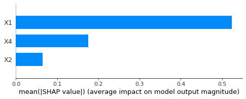

```python
shap.summary_plot(shap_values, X_test_f, plot_type='bar')
```

## How everything changes in global level

```python
shap.initjs()
shap.force_plot(explainer.expected_value,
                shap_values[:,:], X_test_f.iloc[:,:])
```

**Visualization omitted, Javascript library not loaded!**  
Have you run `initjs()` in this notebook? If this notebook was from another user you must also trust this notebook (File -> Trust notebook). If you are viewing this notebook on github the Javascript has been stripped for security. If you are using JupyterLab this error is because a JupyterLab extension has not yet been written.

# For Linear Regression

I wanted to try it on Linear regression model to see how it predicts and if I can improve my model in any way.

```python
# We will use a "Linear Explainer" since Logistic regression is a Linear Model

lin_explainer = shap.LinearExplainer(model_linear, X_train)
lin_shap_values = lin_explainer.shap_values(X_test)
pd.DataFrame(lin_shap_values, columns=X_test.columns).head(5)
```

```
The feature_perturbation option is now deprecated in favor of using the appropriate masker (maskers.Independent, or maskers.Impute)
```

|  | X1 | X2 | X3 | X4 | X5 | X6 |
| --- | --- | --- | --- | --- | --- | --- |
| 0 | -0.033626 | 0.030451 | 0.047069 | 0.001047 | 0.008222 | 0.001003 |
| 1 | 0.074845 | 0.030451 | -0.018305 | -0.002831 | 0.008222 | 0.001003 |
| 2 | -0.033626 | -0.009616 | -0.018305 | 0.001047 | -0.038763 | 0.001003 |
| 3 | -0.033626 | -0.009616 | -0.018305 | -0.002831 | -0.015270 | 0.001003 |
| 4 | 0.074845 | -0.049683 | 0.112442 | -0.006710 | 0.031715 | -0.002457 |

```python
print('Expected Value:', lin_explainer.expected_value)
```

```
Expected Value: 0.56
```

```python
print("Test data (actual observation): {}".format(y_test.iloc[0]))
print("Model's prediction: {}".format(pred_linear[0]))
```

```
Test data (actual observation): 0
Model's prediction: 0.6141664106523897
```

As the predicted value is below 0.65 it can be considered as an unhappy customer, so our linear model predicted correctly.

```python
shap.initjs()
shap.force_plot(lin_explainer.expected_value, lin_shap_values[3, :], X_test.iloc[3, :])
```

**Visualization omitted, Javascript library not loaded!**  
Have you run `initjs()` in this notebook? If this notebook was from another user you must also trust this notebook (File -> Trust notebook). If you are viewing this notebook on github the Javascript has been stripped for security. If you are using JupyterLab this error is because a JupyterLab extension has not yet been written.

```python
print("Test data (actual observation): {}".format(y_test.iloc[1]))
print("Model's prediction: {}".format(pred_linear[1]))
```

```
Test data (actual observation): 1
Model's prediction: 0.6533859149528501
```

Predicted value is > 0.65 so it is considered as a happy customer, predicted correctly.

```python
shap.initjs()
shap.force_plot(lin_explainer.expected_value, lin_shap_values[1, :], X_test.iloc[1, :])
```

**Visualization omitted, Javascript library not loaded!**  
Have you run `initjs()` in this notebook? If this notebook was from another user you must also trust this notebook (File -> Trust notebook). If you are viewing this notebook on github the Javascript has been stripped for security. If you are using JupyterLab this error is because a JupyterLab extension has not yet been written.

## Importances according to linear model

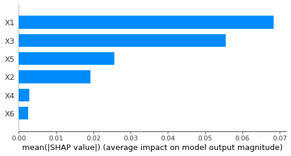

```python
shap.summary_plot(lin_shap_values, X_test, plot_type='bar')
```

```python
shap.initjs()
shap.force_plot(lin_explainer.expected_value,
                lin_shap_values[:,:], X_test.iloc[:,:])
```

**Visualization omitted, Javascript library not loaded!**  
Have you run `initjs()` in this notebook? If this notebook was from another user you must also trust this notebook (File -> Trust notebook). If you are viewing this notebook on github the Javascript has been stripped for security. If you are using JupyterLab this error is because a JupyterLab extension has not yet been written.